# Inferência: testes de permutação e p-valores

Nazareno Andrade

# Intro

Técnicas de Reamostragem = {Bootstrap, Permutação, (jacknifing), …}

Disclaimer: em princípio tudo pode ser feito através de ICs, porém você verá e ouvirá falar muito de p-valores e testes como t-test, mann-withney, wilcoxon e Chi-squared. Então falaremos deles também.

## Os dados

```r
ratings_raw <- read_csv(here("dados", "ml-latest-small", "ratings.csv"), col_types = "ccdi")
movies <- read_csv(here("dados", "ml-latest-small", "movies.csv"), col_types = "ccc")
ratings = full_join(ratings_raw, movies, by = "movieId")
glimpse(ratings)
```

```
Observations: 105,343
Variables: 6
$ userId    <chr> "1", "1", "1", "1", "1", "1", "1", "1", "1", "1", "1", "1", "1", "1", "1", "1", "1", "1", "1", "1"...
$ movieId   <chr> "16", "24", "32", "47", "50", "110", "150", "161", "165", "204", "223", "256", "260", "261", "277"...
$ rating    <dbl> 4.0, 1.5, 4.0, 4.0, 4.0, 4.0, 3.0, 4.0, 3.0, 0.5, 4.0, 0.5, 4.5, 1.5, 0.5, 4.0, 4.0, 4.5, 3.0, 2.5...
$ timestamp <int> 1217897793, 1217895807, 1217896246, 1217896556, 1217896523, 1217896150, 1217895940, 1217897864, 12...
$ title     <chr> "Casino (1995)", "Powder (1995)", "Twelve Monkeys (a.k.a. 12 Monkeys) (1995)", "Seven (a.k.a. Se7e...
$ genres    <chr> "Crime|Drama", "Drama|Sci-Fi", "Mystery|Sci-Fi|Thriller", "Mystery|Thriller", "Crime|Mystery|Thril...
```

Focaremos em alguns episódios de Star Wars

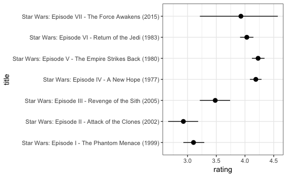

```r
sw = ratings %>% filter(grepl("Star Wars", title) &
                          (grepl("Episode IV -", title) |
                             grepl("Episode I -", title) |
                             grepl("Episode V -", title)))
sw = ratings %>% filter(grepl("Star Wars", title) &
                          (grepl("Episode ", title)))
ggplot(sw, aes(y = rating, x = title)) +
  stat_summary(fun.data = "mean_cl_boot") +
  coord_flip()
```

```r
nomes_episodios = c("Star Wars: Episode I - The Phantom Menace (1999)",
                    "", # não usamos
                    "", # não usamos
                    "Star Wars: Episode IV - A New Hope (1977)",
                    "Star Wars: Episode V - The Empire Strikes Back (1980)",
                    "Star Wars: Episode VI - Return of the Jedi (1983)")

sw5x6 = sw %>%
  filter(title %in% c(nomes_episodios[5],
                      nomes_episodios[6])) %>%
  select(title, rating)
sw4x5 = sw %>%
  filter(title %in% c(nomes_episodios[4],
                      nomes_episodios[5])) %>%
  select(title, rating)
```

# Nosso framework

## Manual

Vamos guardar as diferenças observadas na nossa amostra para o episódio 5 x 6.

```r
medias5x6 = sw5x6 %>%
  group_by(title) %>%
  summarise(media = mean(rating))
medias5x6
```

| title | media |
| --- | --- |
| Star Wars: Episode V - The Empire Strikes Back (1980) | 4.228070 |
| Star Wars: Episode VI - Return of the Jedi (1983) | 4.031532 |

```r
diff.media.observada.5x6 = diff(medias5x6$media)
```

Mesma coisa para o episódio 4 x 5.

```r
medias4x5 = sw4x5 %>%
  group_by(title) %>%
  summarise(media = mean(rating))
medias4x5
```

| title | media |
| --- | --- |
| Star Wars: Episode IV - A New Hope (1977) | 4.188645 |
| Star Wars: Episode V - The Empire Strikes Back (1980) | 4.228070 |

```r
diff.media.observada.4x5 = diff(medias4x5$media)
```

Agora vejamos o quão frequente seria encontrarmos uma diferença do tamanho que encontramos *se não houvesse associação nenhuma entre qual é o episódio e qual é a avaliação que ele recebe*. A situação onde não existe associação é a *hipótese nula*. Se a diferença que observamos em nossa amostra acontece facilmente na hipótese nula, isso significa que não temos evidência forte de associação: o que observamos acontece também quando não há associação.

No caso onde a diferença que observamos é improvável na hipótese nula, então observamos algo que é indicativo de associação. Repare que é uma dupla negação: se **não acontece** associação como a que vimos na amostra na situação onde **não** há associação, então temos evidência de que há associação.

Concretameente, para os Episódios 5 x 6:

```r
set.seed(1)
glimpse(sw5x6)
```

```
Observations: 450
Variables: 2
$ title  <chr> "Star Wars: Episode V - The Empire Strikes Back (1980)", ...
$ rating <dbl> 4.5, 4.5, 4.0, 5.0, 5.0, 5.0, 5.0, 4.0, 5.0, 5.0, 4.5, 4....
```

```r
diffs = replicate(10000, {
  medias = sw5x6 %>%
    mutate(id_embaralhado = sample(title, n())) %>%
    group_by(id_embaralhado) %>%
    summarise(media = mean(rating))
  e5 = medias %>%
    filter(id_embaralhado == nomes_episodios[5])
  e6 = medias %>%
    filter(id_embaralhado == nomes_episodios[6])
  return(e5$media - e6$media)
})
glimpse(diffs)
```

```
 num [1:10000] -0.0391 -0.1946 -0.0479 -0.0746 0.0632 ...
```

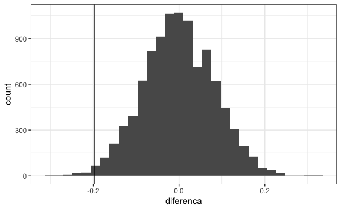

```r
tibble(diferenca = diffs) %>%
  ggplot(aes(x = diferenca)) +
  geom_histogram(bins = 30) +
  geom_vline(xintercept = diff.media.observada.5x6)
```

```r
# p-valor!
sum(abs(diffs) >= abs(diff.media.observada.5x6)) / length(diffs)
```

```
[1] 0.0168
```

Episódio 4 x 5

```r
set.seed(1)
glimpse(sw4x5)
```

```
Observations: 501
Variables: 2
$ title  <chr> "Star Wars: Episode IV - A New Hope (1977)", "Star Wars: ...
$ rating <dbl> 4.5, 4.5, 4.0, 4.0, 5.0, 5.0, 4.0, 4.0, 5.0, 5.0, 5.0, 5....
```

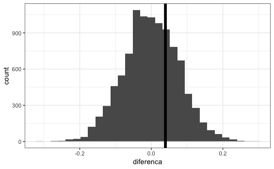

```r
diffs = replicate(10000, {
  medias = sw4x5 %>%
    mutate(id_embaralhado = sample(title, n())) %>%
    group_by(id_embaralhado) %>%
    summarise(media = mean(rating))
  e5 = medias %>%
    filter(id_embaralhado == nomes_episodios[5])
  e4 = medias %>%
    filter(id_embaralhado == nomes_episodios[4])
  return(e4$media - e5$media)
})
tibble(diferenca = diffs) %>%
  ggplot(aes(x = diferenca)) +
  geom_histogram(bins = 30) +
  geom_vline(xintercept = diff.media.observada.4x5, size = 2)
```

```r
sum(abs(diffs) >= abs(diff.media.observada.4x5)) / length(diffs)
```

```
[1] 0.621
```

## Pacote coin

Teste da média

```r
library(coin)
oneway_test(rating ~ as.factor(title),
            data = sw5x6,
            distribution = "exact")
```

```
    Exact Two-Sample Fisher-Pitman Permutation Test

data:  rating by
     as.factor(title) (Star Wars: Episode V - The Empire Strikes Back (1980), Star Wars: Episode VI - Return of the Jedi (1983))
Z = 2.4068, p-value = 0.01635
alternative hypothesis: true mu is not equal to 0
```

```r
oneway_test(rating ~ as.factor(title),
            data = sw4x5,
            distribution = "exact") %>%
  pvalue()
```

```
[1] 0.6192216
```

Teste de que a mediana das populações de onde vieram as avaliações dos episódios são diferentes:

```r
median_test(rating ~ as.factor(title),
            data = sw5x6,
            distribution = "exact")
```

```
    Exact Two-Sample Brown-Mood Median Test

data:  rating by
     as.factor(title) (Star Wars: Episode V - The Empire Strikes Back (1980), Star Wars: Episode VI - Return of the Jedi (1983))
Z = 1.8238, p-value = 0.0725
alternative hypothesis: true mu is not equal to 0
```

```r
median_test(rating ~ as.factor(title),
            data = sw4x5,
            distribution = "exact")
```

```
    Exact Two-Sample Brown-Mood Median Test

data:  rating by
     as.factor(title) (Star Wars: Episode IV - A New Hope (1977), Star Wars: Episode V - The Empire Strikes Back (1980))
Z = -0.024689, p-value = 1
alternative hypothesis: true mu is not equal to 0
```

```r
permutationTest2(sw4x5, median(rating), treatment = title)$stats %>% t()
```

```
            median(rating): Star Wars: Episode IV - A New Hope (1977)-Star Wars: Episode V - The Empire Strikes Back (1980)
Observed    "0"
Mean        "-0.005325533"
Alternative "two.sided"
PValue      "1"
```

## Por que two-tailed

Normalmente estamos interessados em rejeitar a hipótese nula da igualdade. A igualdade está em torno do zero, e portanto a rejeição acontece quando o valor observado está longe de zero em qualquer direção. Existem testes one-tailed que não dão informação sobre se há diferença nas duras direções. Porém na prática é uma prática requerida que você decida o teste antes de realizá-lo, e é difícil decidir que apenas diferenças em uma direção serão relevantes. Além disso, devido à pressão por resultado, decidir usar one-tailed é sempre um truque que aumenta sua chance de produzir um teste com diferença significativa, o que é claramente uma manipulação na sua metodologia.

# Testes conhecidos que você pode encontrar

## Mann-withney-wilcoxon

Testa se a soma dos ranks das duas amostras são significativamente diferentes.

```r
library("coin")
wilcox_test(rating ~ as.factor(title),
            data = sw5x6,
            distribution = "exact") # tirando este parâmetro, usamos fórmula fechada em lugar de permutação
```

```
    Exact Wilcoxon-Mann-Whitney Test

data:  rating by
     as.factor(title) (Star Wars: Episode V - The Empire Strikes Back (1980), Star Wars: Episode VI - Return of the Jedi (1983))
Z = 2.5638, p-value = 0.01027
alternative hypothesis: true mu is not equal to 0
```

## Chi-squared para associação entre duas variávies categóricas

```r
titanic = read.csv(here("dados", "titanic.csv"))
titanic = titanic %>%
  mutate(Survived = as.factor(Survived),
         Pclass = as.factor(Pclass))
table(titanic$Survived, titanic$Pclass)
```

```
      1   2   3
  0  80  97 372
  1 136  87 119
```

```r
chisq.test(titanic$Survived, titanic$Pclass, simulate.p.value = TRUE)
```

```
    Pearson's Chi-squared test with simulated p-value (based on 2000
    replicates)

data:  titanic$Survived and titanic$Pclass
X-squared = 102.89, df = NA, p-value = 0.0004998
```

```r
chisq.test(titanic$Survived, titanic$Pclass, simulate.p.value = TRUE)$resid
```

```
                titanic$Pclass
titanic$Survived         1         2         3
               0 -4.601993 -1.537771  3.993703
               1  5.830678  1.948340 -5.059981
```

```r
library(gmodels)
CrossTable(titanic$Survived,
           titanic$Pclass,
           prop.t = F,
           resid = TRUE)
```

```
   Cell Contents
|-------------------------|
|                       N |
| Chi-square contribution |
|           N / Row Total |
|           N / Col Total |
|-------------------------|


Total Observations in Table:  891


                 | titanic$Pclass
titanic$Survived |         1 |         2 |         3 | Row Total |
-----------------|-----------|-----------|-----------|-----------|
               0 |        80 |        97 |       372 |       549 |
                 |    21.178 |     2.365 |    15.950 |           |
                 |     0.146 |     0.177 |     0.678 |     0.616 |
                 |     0.370 |     0.527 |     0.758 |           |
-----------------|-----------|-----------|-----------|-----------|
               1 |       136 |        87 |       119 |       342 |
                 |    33.997 |     3.796 |    25.603 |           |
                 |     0.398 |     0.254 |     0.348 |     0.384 |
                 |     0.630 |     0.473 |     0.242 |           |
-----------------|-----------|-----------|-----------|-----------|
    Column Total |       216 |       184 |       491 |       891 |
                 |     0.242 |     0.207 |     0.551 |           |
-----------------|-----------|-----------|-----------|-----------|
```

```r
# library(vcd)
#mosaic(table(titanic$Survived, titanic$Pclass), shade = TRUE)
```

Outro

```r
titanic2 <- read.csv(url("http://whitlockschluter.zoology.ubc.ca/wp-content/data/chapter09/chap09f1.1Titanic.csv"))
head(titanic2)
```

|  | sex | survival |
| --- | --- | --- |
| 1 | Men | Survived |
| 2 | Men | Survived |
| 3 | Men | Survived |
| 4 | Men | Survived |
| 5 | Men | Survived |
| 6 | Men | Survived |

```r
titanicTable <- table(titanic2$survival, titanic2$sex)
addmargins(titanicTable)
```

```
            Men Women  Sum
  Died     1329   109 1438
  Survived  338   316  654
  Sum      1667   425 2092
```

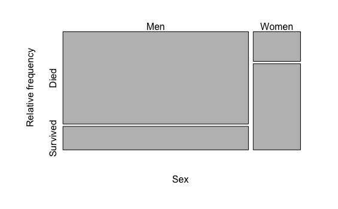

```r
mosaicplot(t(titanicTable),
           cex.axis = 1,
           sub = "Sex",
           ylab = "Relative frequency", main = "")
```

[output not shown]

[figure not shown]

```r
library(vcd)
mosaic(table(titanic2$survival, titanic2$sex))
```

## Outra alternativa: pacote resample

Os p-valores dão diferente daqueles calculados pelo pacote `coin`, e ainda não descobri a razão exata.

```r
library(resample)
permutationTest2(data = sw5x6, statistic = mean(rating), treatment = title)
```

```
Call:
permutationTest2(data = sw5x6, statistic = mean(rating), treatment = title)
Replications: 9999
Two samples, sample sizes are 228 222

Summary Statistics for the difference between samples 1 and 2:
                                                                                                                       Observed
mean(rating): Star Wars: Episode V - The Empire Strikes Back (1980)-Star Wars: Episode VI - Return of the Jedi (1983) 0.1965386
                                                                                                                              Mean
mean(rating): Star Wars: Episode V - The Empire Strikes Back (1980)-Star Wars: Episode VI - Return of the Jedi (1983) 0.0005173467
                                                                                                                      Alternative
mean(rating): Star Wars: Episode V - The Empire Strikes Back (1980)-Star Wars: Episode VI - Return of the Jedi (1983)   two.sided
                                                                                                                      PValue
mean(rating): Star Wars: Episode V - The Empire Strikes Back (1980)-Star Wars: Episode VI - Return of the Jedi (1983) 0.0014
```

```r
permutationTest2(data = sw5x6 %>% filter(title == nomes_episodios[6]),
                 statistic = mean(rating),
                 data2 = sw5x6 %>% filter(title == nomes_episodios[5]))
```

```
Call:
permutationTest2(data = sw5x6 %>% filter(title == nomes_episodios[6]),
    statistic = mean(rating), data2 = sw5x6 %>% filter(title ==
        nomes_episodios[5]))
Replications: 9999
Two samples, sample sizes are 222 228

Summary Statistics for the difference between samples 1 and 2:
                           Observed         Mean Alternative PValue
mean(rating): data-data2 -0.1965386 0.0002852348   two.sided  0.001
```

```r
permutationTest2(sw4x5, mean(rating), treatment = title)
```

```
Call:
permutationTest2(data = sw4x5, statistic = mean(rating), treatment = title)
Replications: 9999
Two samples, sample sizes are 273 228

Summary Statistics for the difference between samples 1 and 2:
                                                                                                                 Observed
mean(rating): Star Wars: Episode IV - A New Hope (1977)-Star Wars: Episode V - The Empire Strikes Back (1980) -0.03942549
                                                                                                                       Mean
mean(rating): Star Wars: Episode IV - A New Hope (1977)-Star Wars: Episode V - The Empire Strikes Back (1980) -0.0002161629
                                                                                                              Alternative
mean(rating): Star Wars: Episode IV - A New Hope (1977)-Star Wars: Episode V - The Empire Strikes Back (1980)   two.sided
                                                                                                              PValue
mean(rating): Star Wars: Episode IV - A New Hope (1977)-Star Wars: Episode V - The Empire Strikes Back (1980) 0.4708
```

```r
permutationTest2(sw5x6, median(rating), treatment = title)
```

```
Call:
permutationTest2(data = sw5x6, statistic = median(rating), treatment = title)
Replications: 9999
Two samples, sample sizes are 228 222

Summary Statistics for the difference between samples 1 and 2:
                                                                                                                        Observed
median(rating): Star Wars: Episode V - The Empire Strikes Back (1980)-Star Wars: Episode VI - Return of the Jedi (1983)        0
                                                                                                                               Mean
median(rating): Star Wars: Episode V - The Empire Strikes Back (1980)-Star Wars: Episode VI - Return of the Jedi (1983) -0.00080008
                                                                                                                        Alternative
median(rating): Star Wars: Episode V - The Empire Strikes Back (1980)-Star Wars: Episode VI - Return of the Jedi (1983)   two.sided
                                                                                                                        PValue
median(rating): Star Wars: Episode V - The Empire Strikes Back (1980)-Star Wars: Episode VI - Return of the Jedi (1983)      1
```

```r
permutationTest2(sw4x5, median(rating), treatment = title)
```

```
Call:
permutationTest2(data = sw4x5, statistic = median(rating), treatment = title)
Replications: 9999
Two samples, sample sizes are 273 228

Summary Statistics for the difference between samples 1 and 2:
                                                                                                                Observed
median(rating): Star Wars: Episode IV - A New Hope (1977)-Star Wars: Episode V - The Empire Strikes Back (1980)        0
                                                                                                                      Mean
median(rating): Star Wars: Episode IV - A New Hope (1977)-Star Wars: Episode V - The Empire Strikes Back (1980) -0.0080008
                                                                                                                Alternative
median(rating): Star Wars: Episode IV - A New Hope (1977)-Star Wars: Episode V - The Empire Strikes Back (1980)   two.sided
                                                                                                                PValue
median(rating): Star Wars: Episode IV - A New Hope (1977)-Star Wars: Episode V - The Empire Strikes Back (1980)      1
```